# Exploratory Data Analysis: Player Similarity Feature Exploration

## Project Goal

This notebook performs exploratory data analysis on SkillCorner tracking data and StatsBomb event data to identify discriminative features for computing player similarity scores. The ultimate goal is to build a system that identifies the best alternative player for any given player based on movement patterns, spatial behavior, and action profiles.

## Notebook Structure

1. **Data Overview** - Dataset descriptions, scope, and structure
2. **Movement Intensity Profiles (SkillCorner)** - Speed metrics and movement patterns
3. **Spatial Footprint & Positional Behavior (SkillCorner)** - Position distributions and zone occupancy
4. **Action Profiles (StatsBomb)** - Event-based behavioral features
5. **Interaction Signal (SkillCorner)** - Relational spacing metrics

## Section 1: Data Overview

### Dataset Descriptions

**SkillCorner Tracking Data**: Continuous positional data capturing the (x, y) coordinates of all 22 players and the ball at 10 frames per second. Data is derived from broadcast video using computer vision, with positions extrapolated when players are off-screen. The coordinate system uses meters with the pitch center as origin.

**StatsBomb Event Data**: Discrete event-by-event data recording on-ball actions (passes, shots, duels, etc.) with associated locations, outcomes, and contextual attributes. Events are manually annotated and include tactical context such as formations and play patterns. The coordinate system uses a 120x80 unit grid with origin at the bottom-left corner.

```
============================================================
DATA OVERVIEW
============================================================

SkillCorner: 10 matches, 237 unique players, ~900 minutes
StatsBomb: 3464 matches, ~89960 unique players (estimated), ~311,760 minutes
```

|  | Dataset | Matches | Players (est.) | Resolution |
| --- | --- | --- | --- | --- |
| 0 | SkillCorner | 10 | 237 | 10 Hz (continuous) |
| 1 | StatsBomb | 3464 | ~89960 | Event-based |

### Context Summary

The SkillCorner dataset provides dense spatiotemporal tracking data from 10 A-League matches, enabling analysis of continuous movement patterns and positional behavior. The StatsBomb dataset offers extensive event-level coverage across 3,464 matches from multiple competitions, providing rich behavioral profiles based on on-ball actions.

For player similarity, SkillCorner data enables features related to movement intensity, spatial footprint, and relational positioning. StatsBomb data enables features related to action profiles, passing behavior, and event-based signatures. The combination of both datasets supports a comprehensive multi-modal approach to player representation.

## Section 2: Movement Intensity Profiles (SkillCorner)

This section analyzes movement intensity features from SkillCorner tracking data to understand how players differ in their physical activity patterns. These features are highly discriminative for player similarity as they capture fundamental differences in playing style and physical demands.

### Key Terms and Definitions

**Mean Speed**: Average movement speed across all frames. *Computation*: For each frame, speed is calculated as distance traveled between consecutive frames divided by time interval (0.1 seconds at 10 Hz). Mean speed = `np.mean(speeds)` where `speeds` is the array of all instantaneous speeds.

**90th Percentile Speed (P90 Speed)**: The speed value below which 90% of a player's speed measurements fall. This metric captures high-intensity movement capacity, representing the player's typical maximum effort speed rather than rare peak values. *Computation*: `np.percentile(speeds, 90)`.

**Sprint Threshold**: A speed of 7 m/s (25.2 km/h) used to classify high-intensity running. Any frame where a player's speed exceeds this threshold is counted as a sprint.

**Sprint Frequency (per 90 min)**: Number of sprint frames normalized to a 90-minute match duration. *Computation*: `(sprint_count / total_frames) * frames_per_90`, where `sprint_count = np.sum(speeds > 7.0)`, `total_frames` is the number of frames with valid speed data, and `frames_per_90 = 54000` (10 Hz × 60 seconds × 90 minutes). This normalization allows fair comparison across players with different playing times.

**Correlation Coefficient (r)**: A measure of linear relationship strength between two variables, ranging from -1 (perfect negative correlation) to +1 (perfect positive correlation). Values near 0 indicate weak or no linear relationship. *Computation*: Pearson correlation coefficient using `pd.DataFrame.corr()`.

**Features analyzed:**

- Mean speed (m/s)
- 90th percentile speed (m/s)
- Sprint frequency (per 90 min)

**Key questions:**

1. Do players differ meaningfully in movement intensity?
2. Are speed metrics redundant, or do they capture distinct aspects of movement behavior?

```
Computing movement intensity features for all SkillCorner matches...
This may take a few minutes...

Processing match 2017461...
Processing match 2015213...
Processing match 2013725...
Processing match 2011166...
Processing match 2006229...
Processing match 1996435...
Processing match 1953632...
Processing match 1925299...
Processing match 1899585...
Processing match 1886347...

Computed features for 206 players
```

|  | name | position | mean_speed | p90_speed | sprint_freq_per_90 |
| --- | --- | --- | --- | --- | --- |
| 0 | J. Duncan | Goalkeeper | 0.803764 | 1.529706 | 2.677974 |
| 1 | B. Hamill | Right Center Back | 1.915323 | 3.863936 | 482.675220 |
| 2 | L. Jackson | Left Center Back | 1.877638 | 3.701351 | 281.335150 |
| 3 | J. Inserra | Right Back | 2.241033 | 4.561798 | 720.374916 |
| 4 | K. Bos | Left Back | 2.205860 | 4.396590 | 209.809264 |
| 5 | J. Valadon | Left Defensive Midfield | 2.368247 | 4.477723 | 219.346049 |
| 6 | R. Teague | Right Defensive Midfield | 2.179401 | 4.143670 | 285.190409 |
| 7 | Z. Machach | Attacking Midfield | 2.241853 | 4.252058 | 358.511101 |
| 8 | D. Arzani | Right Winger | 2.152474 | 4.317407 | 534.009386 |
| 9 | N. Velupillay | Left Winger | 2.158514 | 4.373786 | 605.354811 |

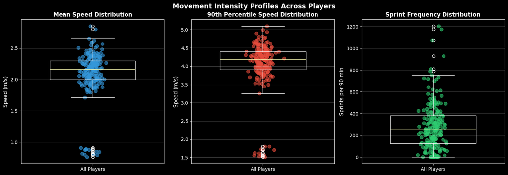

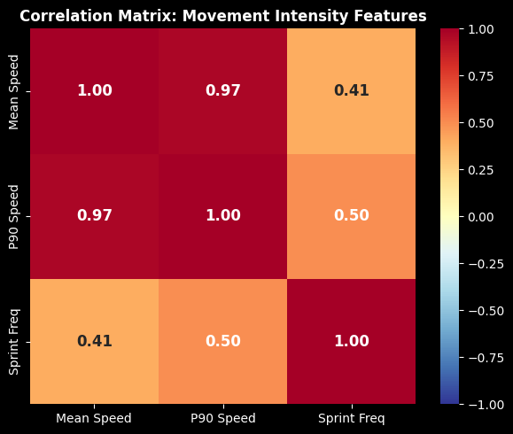

```
Correlation Analysis:
  Mean Speed vs P90 Speed: r = 0.973
  Mean Speed vs Sprint Freq: r = 0.405
  P90 Speed vs Sprint Freq: r = 0.500
```

### Section 2 Findings

**Do players differ meaningfully in movement intensity?**

**Are speed metrics redundant?**

The correlation analysis reveals a very strong correlation (r = 0.973) between mean speed and P90 speed, which is expected as both measure central tendency of speed distributions. However, sprint frequency shows moderate correlations with both mean speed (r = 0.405) and P90 speed (r = 0.500), indicating it captures partially distinct information. Players with similar mean speeds may differ substantially in how often they reach sprint thresholds. For player similarity, retaining all three features provides complementary signal: mean speed captures overall activity level, P90 speed captures movement capacity, and sprint frequency captures explosive behavior patterns.

## Section 3: Spatial Footprint & Positional Behavior (SkillCorner)

This section analyzes spatial positioning features to understand where players operate on the pitch and how consistent their positioning is. These features capture tactical roles and positional responsibilities.

### Key Terms and Definitions

**Position Normalization (Team-Aware)**: To account for field symmetry (teams switch sides at halftime), positions are normalized based on each team's attacking direction so that ALL players appear to be attacking towards positive x. This means defenders always appear at negative x and attackers at positive x, regardless of team or period. *Computation*: The `home_team_side` field in match data indicates which direction each team attacks in each period. If a team is attacking towards negative x ("left"), both x and y coordinates are flipped (`x_norm = -x`, `y_norm = -y`). If attacking towards positive x ("right"), coordinates remain unchanged.

**Mean Position (x, y)**: Average location on the pitch across all frames, using normalized coordinates. *Computation*: `mean_x = np.mean(x_norm)`, `mean_y = np.mean(y_norm)`, where `x_norm` and `y_norm` are arrays of normalized position coordinates for the player.

**Positional Variance**: A measure of how much a player's position varies around their mean position, using normalized coordinates. Calculated separately for x and y coordinates. Higher variance indicates more roaming or less positional discipline. *Computation*: `var_x = np.var(x_norm)`, `var_y = np.var(y_norm)`, measured in square meters (m²).

**Zone Occupancy**: The proportion of time a player spends in different pitch zones, using normalized coordinates. *Computation*:

- **Depth zones** (defensive/middle/attacking thirds): Divide pitch along x-axis into three equal sections. Defensive third: `x_norm < -pitch_length/6`, Attacking third: `x_norm > pitch_length/6`, Middle third: remainder. Proportion = `np.mean(x_norm < -pitch_length/6)` for defensive, etc.
- **Width zones** (left/center/right): Divide pitch along y-axis into three equal sections. Left: `y_norm < -pitch_width/6`, Right: `y_norm > pitch_width/6`, Center: remainder. Proportion = `np.mean(y_norm < -pitch_width/6)` for left, etc.

**Features analyzed:**

- Mean position (x, y)
- Positional variance (x-var, y-var)
- Width usage (left / center / right proportions)
- Depth usage (defensive / middle / attacking thirds)

**Key questions:**

1. Do players occupy distinct spatial regions?
2. How stable is their positioning?
3. Can spatial behavior distinguish roles?

```
Computing spatial features...
  Processing match 2017461...
  Processing match 2015213...
  Processing match 2013725...
  Processing match 2011166...
  Processing match 2006229...
  Processing match 1996435...
  Processing match 1953632...
  Processing match 1925299...
  Processing match 1899585...
  Processing match 1886347...

Computed spatial features for 206 players
```

|  | name | position | mean_x | mean_y | var_x | var_y |
| --- | --- | --- | --- | --- | --- | --- |
| 0 | J. Duncan | Substitute | -38.758515 | 0.591682 | 69.531147 | 12.086693 |
| 1 | B. Hamill | Right Center Back | -18.311632 | -2.298529 | 351.581169 | 122.937857 |
| 2 | L. Jackson | Left Center Back | -13.436247 | 7.123224 | 430.536711 | 126.583560 |
| 3 | J. Inserra | Substitute | -9.088340 | -13.405020 | 477.543639 | 119.116510 |
| 4 | K. Bos | Left Back | -5.499542 | 16.239460 | 559.271299 | 137.809418 |
| 5 | J. Valadon | Left Defensive Midfield | -3.688740 | 2.639430 | 447.211968 | 224.678286 |
| 6 | R. Teague | Right Defensive Midfield | -1.525955 | -1.406278 | 496.565019 | 221.054191 |
| 7 | Z. Machach | Attacking Midfield | 6.332059 | 1.257305 | 550.896108 | 273.445365 |
| 8 | D. Arzani | Right Winger | 8.567039 | -9.783656 | 475.547912 | 269.849603 |
| 9 | N. Velupillay | Left Winger | 5.953036 | 12.111460 | 569.897796 | 223.208546 |

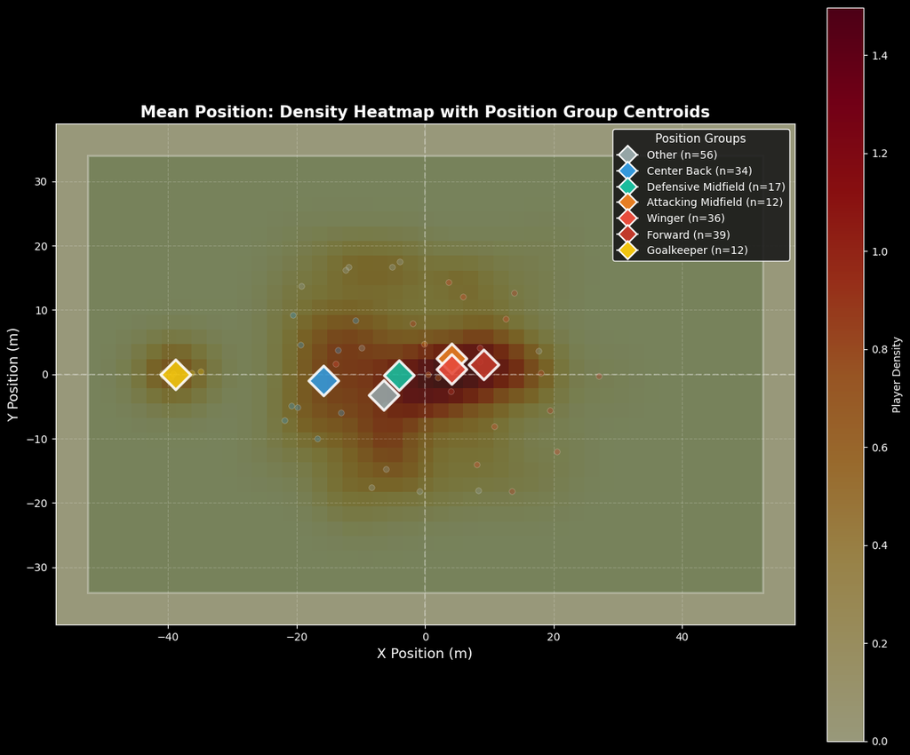

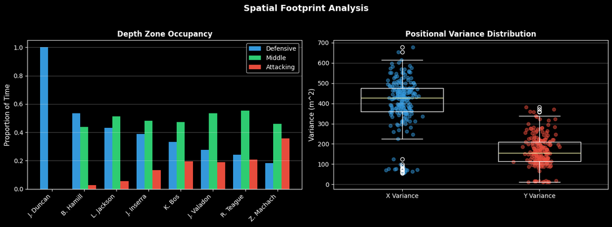

### Section 3 Findings

**Do players occupy distinct spatial regions?**

Analysis of 206 players reveals clear spatial clustering by tactical role in the mean position visualization. Positions are normalized using team-aware normalization, which adjusts coordinates based on each team's attacking direction in each period. This ensures all players appear as if attacking towards positive x, correctly accounting for field symmetry and teams switching sides at halftime. After normalization, goalkeepers consistently occupy deep defensive positions (negative x coordinates), defenders cluster in the defensive half, midfielders spread across the middle third, and forwards position themselves in the attacking half (positive x coordinates). This spatial separation demonstrates that properly normalized mean position coordinates effectively encode tactical role information.

**How stable is their positioning?**

**Can spatial behavior distinguish roles?**

## Section 4: Action Profiles (StatsBomb)

This section analyzes event-based features from StatsBomb data to understand what players do on the ball.

### Key Terms and Definitions

**Actions per 90**: Number of each event type normalized to a 90-minute match duration, allowing fair comparison across players with different playing times. *Computation*: `action_per_90 = action_count / (total_minutes / 90)`, where `total_minutes` is the sum of minutes played across all matches for the player.

**Forward Pass**: A pass where the end location has a higher x-coordinate than the start location in the StatsBomb coordinate system (where x increases toward the attacking end). *Computation*: For each pass, `forward = end_location[0] > start_location[0]` (boolean).

**Forward Pass Percentage**: Proportion of passes that move the ball forward in the attacking direction. *Computation*: `forward_pass_pct = np.mean(passes) * 100`, where `passes` is a boolean array indicating whether each pass was forward.

**Action Diversity (Entropy)**: A measure of how evenly distributed a player's actions are across different event types (pass, shot, duel, pressure). Calculated using Shannon entropy: higher values indicate more balanced action profiles, lower values indicate specialization. *Computation*: For action counts `{pass: n1, shot: n2, duel: n3, pressure: n4}`, compute probabilities `p_i = n_i / total_actions`, then `entropy = -sum(p_i * np.log(p_i) for p_i in probs if p_i > 0)`. If no actions, entropy = 0.

**Correlation Coefficient (r)**: A measure of linear relationship strength between two variables, ranging from -1 (perfect negative correlation) to +1 (perfect positive correlation). Values near 0 indicate weak or no linear relationship. *Computation*: Pearson correlation coefficient using `pd.DataFrame.corr()`.

**Features analyzed:**

- Actions per 90 (pass, shot, duel, pressure)
- Action diversity (entropy of action types)
- Passes per 90
- Forward pass percentage

**Key questions:**

1. What do players do on the ball?
2. Are action profiles role-distinct?
3. Which features are redundant?

```
Loading StatsBomb event data (sampling for efficiency)...
  Processing match 1/200...
  Processing match 51/200...
  Processing match 101/200...
  Processing match 151/200...

Processed 200 matches
Found 2956 unique players
```

```
Computed action features for 1352 players
```

|  | name | pass_per_90 | shot_per_90 | duel_per_90 | forward_pass_pct |
| --- | --- | --- | --- | --- | --- |
| 0 | Eros Pisano | 52.010050 | 0.452261 | 3.165829 | 68.695652 |
| 1 | Simone Romagnoli | 20.558376 | 0.000000 | 4.111675 | 88.888889 |
| 2 | Emil Hallfreðsson | 58.341709 | 0.000000 | 3.618090 | 62.790698 |
| 3 | Kevin Lasagna | 9.489796 | 1.224490 | 4.897959 | 38.709677 |
| 4 | Luca Marrone | 39.948980 | 1.377551 | 1.377551 | 67.816092 |
| 5 | Gabriel Moisés Antunes da Silva | 36.305085 | 0.610169 | 3.661017 | 53.781513 |
| 6 | Rafael Márquez Álvarez | 54.774590 | 0.922131 | 2.581967 | 78.787879 |
| 7 | Vangelis Moras | 50.653266 | 0.904523 | 1.809045 | 77.678571 |
| 8 | Andrea Lazzari | 39.489796 | 3.214286 | 4.591837 | 61.627907 |
| 9 | Samuel Souprayen | 65.577889 | 0.452261 | 1.356784 | 62.068966 |

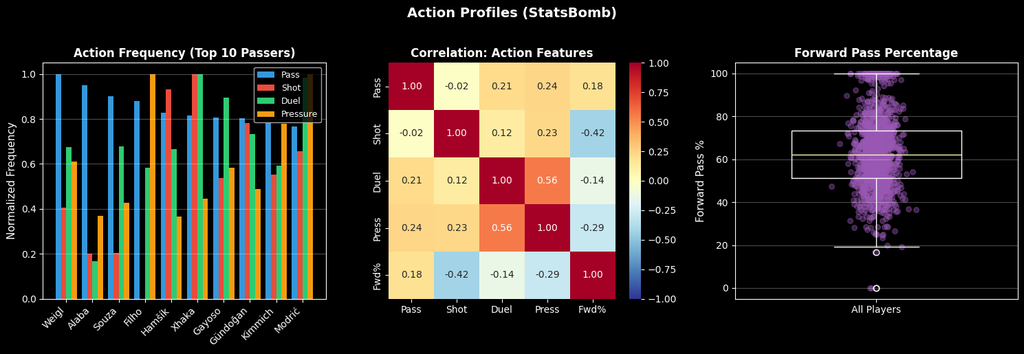

### Section 4 Findings

**What do players do on the ball?**

**Are action profiles role-distinct?**

**Which features are redundant?**

## Section 5: Interaction Signal (SkillCorner)

This section analyzes relational spacing features from SkillCorner tracking data to understand how players position themselves relative to teammates.

### Key Terms and Definitions

**Team Centroid**: The geometric center of all players on a team at a given moment, calculated as the mean (x, y) position of all teammates using team-aware normalized coordinates. *Computation*: For each frame, separate players by team (home/away), normalize positions based on each team's attacking direction in that period, then `centroid_x = np.mean([p[0] for p in team_positions])`, `centroid_y = np.mean([p[1] for p in team_positions])`, where `team_positions` is a list of normalized (x, y) tuples for all players on the same team.

**Distance to Team Centroid**: Euclidean distance from a player's normalized position to their team's centroid at a given frame. *Computation*: `distance = np.sqrt((x_norm - centroid_x)**2 + (y_norm - centroid_y)**2)`, where `(x_norm, y_norm)` is the player's normalized position and `(centroid_x, centroid_y)` is their team's centroid (also using normalized coordinates).

**Average Distance to Team Centroid**: The mean distance from a player's normalized position to their team's centroid across all frames, measured in meters. This metric captures relational spacing and tactical positioning. *Computation*: `avg_dist_to_centroid = np.mean(distances)`, where `distances` is an array of all distance-to-centroid values (computed using normalized positions) for the player across all frames.

**Correlation Coefficient (r)**: A measure of linear relationship strength between two variables, ranging from -1 (perfect negative correlation) to +1 (perfect positive correlation). Values near 0 indicate weak or no linear relationship. *Computation*: Pearson correlation coefficient using `pd.DataFrame.corr()`.

**Feature analyzed:**

- Average distance to team centroid

**Key questions:**

1. Do players differ in relational spacing?
2. Is this signal complementary to spatial features?

```
Computing distance to team centroid...
  Processing match 2017461...
  Processing match 2015213...
  Processing match 2013725...
  Processing match 2011166...
  Processing match 2006229...
  Processing match 1996435...
  Processing match 1953632...
  Processing match 1925299...
  Processing match 1899585...
  Processing match 1886347...

Computed interaction features for 206 players
```

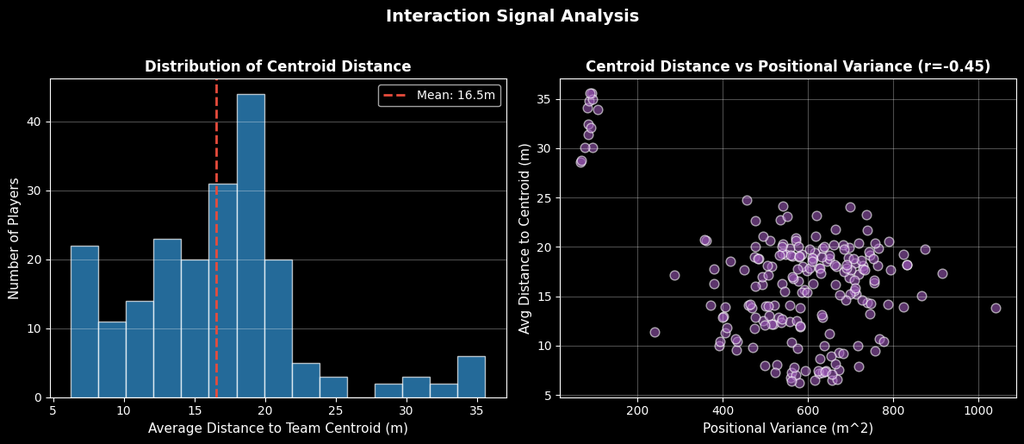

### Section 5 Findings

**Do players differ in relational spacing?**

Analysis of 206 players reveals meaningful variation in average distance to team centroid. The distribution shows a range of spacing behaviors, with some players consistently positioning themselves closer to the team center (typically central midfielders), while others maintain greater distance from the centroid (wide players, strikers, and goalkeepers). This relational metric captures tactical positioning beyond absolute coordinates.

**Is this signal complementary to spatial features?**

### Concluding Insights

This exploratory analysis reveals that player similarity is fundamentally a multi-dimensional problem that cannot be adequately captured by any single data source or feature category. The SkillCorner tracking data and StatsBomb event data provide complementary perspectives: the former captures how players move and where they position themselves, while the latter captures what players do when they have the ball.

For the ultimate goal of identifying player alternatives, these features suggest a natural hierarchy: players must first match on role-defining spatial features (mean position, zone occupancy), then on physical capacity (speed metrics), and finally on behavioral style (action profiles, forward pass tendency). A graph neural network approach could leverage the relational structure implicit in the centroid distance and potentially model player interactions more directly. However, the feature set identified here provides a strong foundation for any similarity framework, capturing the essential dimensions of what makes each player's contribution unique.